# Logistic_Regression_Exercise

Xu Yang

12/7/2017

# Regression with binary outcomes

═════════════════════════════════

## Logistic regression

───────────────────────

This far we have used the `lm' function to fit our regression models.`lm’ is great, but limited–in particular it only fits models for continuous dependent variables. For categorical dependent variables we can use the `glm()’ function.

For these models we will use a different dataset, drawn from the National Health Interview Survey. From the [CDC website]:

```
     The National Health Interview Survey (NHIS) has monitored
     the health of the nation since 1957. NHIS data on a broad
     range of health topics are collected through personal
     household interviews. For over 50 years, the U.S. Census
     Bureau has been the data collection agent for the National
     Health Interview Survey. Survey results have been
     instrumental in providing data to track health status,
     health care access, and progress toward achieving national
     health objectives.
```

[CDC website] http://www.cdc.gov/nchs/nhis.htm

## Load the National Health Interview Survey data:

```r
NH11 <- readRDS("dataSets/NatHealth2011.rds")
labs <- attributes(NH11)$labels
```

## Exercise: logistic regression

───────────────────────────────────

Use the NH11 data set that we loaded earlier.

1. Use glm to conduct a logistic regression to predict ever worked (everwrk) using age (age_p) and marital status (r_maritl).
2. Predict the probability of working for each level of marital status.

Note that the data is not perfectly clean and ready to be modeled. You will need to clean up at least some of the variables before fitting the model.

## Check and Clean Data

```r
summary(NH11$age_p)
```

```
##    Min. 1st Qu.  Median    Mean 3rd Qu.    Max.
##   18.00   33.00   47.00   48.11   62.00   85.00
```

Age range is from 18 to 85

```r
levels(NH11$r_maritl)
```

```
##  [1] "0 Under 14 years"
##  [2] "1 Married - spouse in household"
##  [3] "2 Married - spouse not in household"
##  [4] "3 Married - spouse in household unknown"
##  [5] "4 Widowed"
##  [6] "5 Divorced"
##  [7] "6 Separated"
##  [8] "7 Never married"
##  [9] "8 Living with partner"
## [10] "9 Unknown marital status"
```

```r
summary(NH11$r_maritl)
```

```
##                        0 Under 14 years
##                                       0
##         1 Married - spouse in household
##                                   13943
##     2 Married - spouse not in household
##                                     531
## 3 Married - spouse in household unknown
##                                       0
##                               4 Widowed
##                                    3069
##                              5 Divorced
##                                    4511
##                             6 Separated
##                                    1121
##                         7 Never married
##                                    7763
##                   8 Living with partner
##                                    2002
##                9 Unknown marital status
##                                      74
```

“0 under 14 years” and “3 Married -spouse in household unknown” don’t have any record, so we can remove those two from levels

```r
NH11$r_maritl <- factor(NH11$r_maritl)
levels(NH11$r_maritl)
```

```
## [1] "1 Married - spouse in household"
## [2] "2 Married - spouse not in household"
## [3] "4 Widowed"
## [4] "5 Divorced"
## [5] "6 Separated"
## [6] "7 Never married"
## [7] "8 Living with partner"
## [8] "9 Unknown marital status"
```

```r
summary(NH11$everwrk)
```

```
##             1 Yes              2 No         7 Refused 8 Not ascertained
##             12153              1887                17                 0
##      9 Don't know              NA's
##                 8             18949
```

We just need two levels for ‘everwrk’ variable.

```r
NH11$everwrk <- factor(NH11$everwrk, levels=c("2 No", "1 Yes"))
```

Remove those records whose everwrk have a value NA

```r
NH11_2<-NH11[!is.na(NH11$everwrk),]
```

## Generate the logistic regression

```r
everwrk.out <- glm(everwrk~age_p+r_maritl,
               data=NH11_2, family="binomial")
summary(everwrk.out)
```

```
##
## Call:
## glm(formula = everwrk ~ age_p + r_maritl, family = "binomial",
##     data = NH11_2)
##
## Deviance Residuals:
##     Min       1Q   Median       3Q      Max
## -2.7308   0.3370   0.4391   0.5650   1.0436
##
## Coefficients:
##                                              Estimate Std. Error z value
## (Intercept)                                  0.440248   0.093538   4.707
## age_p                                        0.029812   0.001645  18.118
## r_maritl2 Married - spouse not in household -0.049675   0.217310  -0.229
## r_maritl4 Widowed                           -0.683618   0.084335  -8.106
## r_maritl5 Divorced                           0.730115   0.111681   6.538
## r_maritl6 Separated                          0.128091   0.151366   0.846
## r_maritl7 Never married                     -0.343611   0.069222  -4.964
## r_maritl8 Living with partner                0.443583   0.137770   3.220
## r_maritl9 Unknown marital status            -0.395480   0.492967  -0.802
##                                             Pr(>|z|)
## (Intercept)                                 2.52e-06 ***
## age_p                                        < 2e-16 ***
## r_maritl2 Married - spouse not in household  0.81919
## r_maritl4 Widowed                           5.23e-16 ***
## r_maritl5 Divorced                          6.25e-11 ***
## r_maritl6 Separated                          0.39742
## r_maritl7 Never married                     6.91e-07 ***
## r_maritl8 Living with partner                0.00128 **
## r_maritl9 Unknown marital status             0.42241
## ---
## Signif. codes:  0 '***' 0.001 '**' 0.01 '*' 0.05 '.' 0.1 ' ' 1
##
## (Dispersion parameter for binomial family taken to be 1)
##
##     Null deviance: 11082  on 14039  degrees of freedom
## Residual deviance: 10309  on 14031  degrees of freedom
## AIC: 10327
##
## Number of Fisher Scoring iterations: 5
```

## Create a dataset group by r_maritl with mean age

```r
library(dplyr)
predDat_wrk <-as.data.frame( NH11_2%>%group_by(r_maritl)%>%summarise(age_p=mean(age_p)) )
predDat_wrk
```

```
##                              r_maritl    age_p
## 1     1 Married - spouse in household 57.42708
## 2 2 Married - spouse not in household 56.75472
## 3                           4 Widowed 75.84631
## 4                          5 Divorced 59.87939
## 5                         6 Separated 50.83512
## 6                     7 Never married 36.78192
## 7               8 Living with partner 41.49251
## 8            9 Unknown marital status 59.79412
```

## predict everwrk for each level of r_maritl

```r
predict_result<-cbind(predDat_wrk, predict(everwrk.out, type = "response",
                       se.fit = TRUE, interval="confidence",
                       newdata = predDat_wrk))
predict_result
```

```
##                              r_maritl    age_p       fit      se.fit
## 1     1 Married - spouse in household 57.42708 0.8958812 0.004168800
## 2 2 Married - spouse not in household 56.75472 0.8891960 0.021018793
## 3                           4 Widowed 75.84631 0.8826507 0.006383420
## 4                          5 Divorced 59.87939 0.9505227 0.004845358
## 5                         6 Separated 50.83512 0.8893231 0.014282771
## 6                     7 Never married 36.78192 0.7673105 0.008072894
## 7               8 Living with partner 41.49251 0.8929097 0.012322697
## 8            9 Unknown marital status 59.79412 0.8614472 0.058611653
##   residual.scale
## 1              1
## 2              1
## 3              1
## 4              1
## 5              1
## 6              1
## 7              1
## 8              1
```

predict_result shows that “5 Divorced” has highest probability of working which is 0.9505; “Never married” has lowest probability of working which is 0.7673.

## Use the effects package to compute quantities of interest for us (cf. the Zelig package).

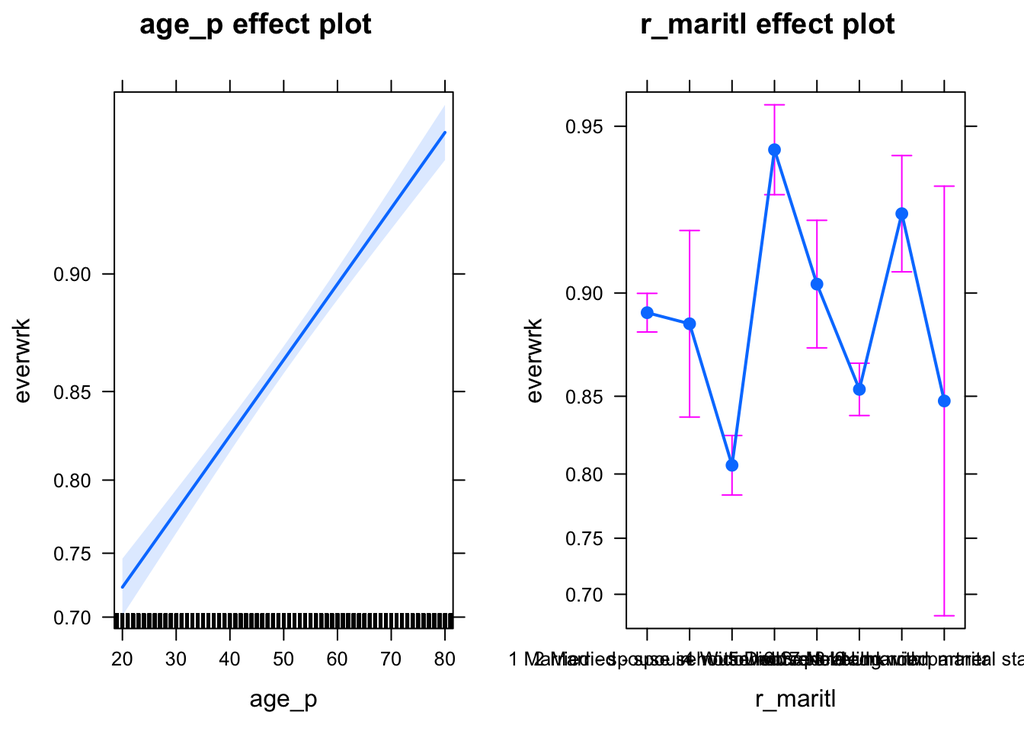

```r
library(effects)
plot(allEffects(everwrk.out))
```